# Binary Models — Individual Predictors

# Overview

This script fits a series of Bayesian binary logistic models predicting climbing behavior (arboreal vs. terrestrial) from individual postcranial skeletal measurements. One model is fit per predictor variable. Models include species and phylogenetic random effects, and use a custom Bernoulli family to handle species with unknown locomotion (see Binary_Multiple_Predictors.Rmd for details on that approach).

Variable types: - Linear measurements: include log body mass as a covariate - Functional ratios/indices: do NOT include size (testing showed no effect on estimates or predictions; see Supplementary for details)

Models are organized into lists by variable type and saved for downstream use.

# 1. Setup

```r
# Load cleaned data (wrangling done in Code/Data_Load.Rmd)
dat <- read_csv(here("Data", "Clean_Data.csv")) #|>
 # filter(Genus_species %in% c("Podomys_floridanus", "Ochrotomys_nuttalli",
 #                             "Peromyscus_gossypinus", "Peromyscus_polionotus"))

# Species in the dataset (needed to prune the phylogeny)
spp_obs <- dat$Taxon_Upham_style %>% unique()

# Variable lists — organized by measurement type and missingness
# These are loaded from pre-saved objects to keep this script focused on modeling
var_complete       <- read_rds(here("Data", "var_complete.Rds"))
var_missing        <- read_rds(here("Data", "var_missing.Rds"))
var_complete_linear <- read_rds(here("Data", "var_complete_linear.Rds"))
var_missing_linear  <- read_rds(here("Data", "var_missing_linear.Rds"))
var_complete_ratio  <- read_rds(here("Data", "var_complete_ratio.Rds"))
var_missing_ratio   <- read_rds(here("Data", "var_missing_ratio.Rds"))
```

```r
# Load phylogenetic tree and compute correlation matrix
# vcv.phylo() returns a variance-covariance matrix used as a prior
# for the phylogenetic random effect in brms
tr <- ape::read.nexus(here("Data", "MCC_Upham_all_mammals.nex"))
tr <- ape::keep.tip(tr, spp_obs)
A  <- ape::vcv.phylo(tr, corr = TRUE)
```

# 2. Custom Bernoulli Family

Species with unknown locomotion (Loc_bin = NA) are excluded from the likelihood but still contribute to the imputation submodels. See Binary_Multiple_Predictors.Rmd for full explanation.

```r
# Create response variable and observation indicator
# Loc_bin_obs = -1  → unknown locomotion (excluded from likelihood)
# Loc_bin_obs >= 0  → known locomotion (standard Bernoulli likelihood)
dat <- dat %>%
  mutate(
    Loc_bin_obs = ifelse(is.na(Loc_bin), -1L, as.integer(Loc_bin)),
    y_for_brms  = ifelse(is.na(Loc_bin),  0L, as.integer(Loc_bin))
  )

# Custom family definition
bernoulli_missing <- custom_family(
  name  = "bernoulli_missing",
  dpars = "mu",
  links = "logit",
  lb = 0, ub = 1,
  type = "int",
  vars = "vint1[n]"
)

# Stan function: standard likelihood for known observations, zero for unknown
stan_funs <- "
  real bernoulli_missing_lpmf(int y_placeholder, real mu, int y_obs) {
    if (y_obs >= 0) {
      return bernoulli_lpmf(y_obs | mu);
    } else {
      return 0;
    }
  }
"
stanvars <- stanvar(scode = stan_funs, block = "functions")
```

# 3. Linear Measurement Models

Linear measurements are fit with log body mass as a covariate. Body mass is itself sometimes missing, so it is also imputed via a submodel.

All predictors are z-scored prior to modeling (done in Data_Load.Rmd), so coefficients are on a comparable scale.

## 3a. Linear measurements with predictor missing

For variables with some missing values, both the focal predictor and log_Mass are imputed jointly with the main model.

```r
# Initialize list to store all linear models
list_b_lm <- vector(mode = "list")
```

```r
# Loop over linear variables with missing data
# Each iteration fits a three-part multivariate model:
#   1. bin_mod:  binary climbing outcome ~ focal predictor + log_Mass + random effects
#   2. imp_mod:  imputation submodel for the focal predictor
#   3. mass_mod: imputation submodel for log_Mass
# Priors must be set inside the loop because get_prior() is formula-dependent
# (update() cannot be used with multivariate models)

for (i in var_missing_linear) {

  bin_mod <- bf(
    paste0("y_for_brms | vint(Loc_bin_obs) ~ mi(", i, ") + mi(log_Mass) +
            (1|Genus_species) + (1|gr(Taxon_Upham_style, cov = A))")
  ) + bernoulli_missing

  imp_mod <- bf(
    paste0(i, " | mi() ~ Fl + Fdw + Fsw + Tpw + Hl + Hdw + Hpw + Hsw + Uol + Mtl +
            (1|gr(Taxon_Upham_style, cov = A))")
  ) + gaussian()

  mass_mod <- bf(
    "log_Mass | mi() ~ Fl + Fdw + Fsw + Tpw + Hl + Hdw + Hpw + Hsw + Uol + Mtl +
     (1|gr(Taxon_Upham_style, cov = A))"
  ) + gaussian()

  m_form <- bin_mod + imp_mod + mass_mod + set_rescor(FALSE)

  # Priors set per response class:
  # - Tighter SD prior for binary outcome (phylo/species signal is small)
  # - Wider SD prior for Gaussian imputation submodels
  pri <- get_prior(m_form, data2 = list(A = A), data = dat) %>%
    mutate(
      prior = case_when(
        class == "b" & coef == ""                       ~ "normal(0, 2)",
        class == "sd" & coef == "" & resp == "yforbrms" ~ "normal(0, 0.3)",
        class == "sd" & coef == "" & resp != "yforbrms" ~ "normal(0, 1)",
        class == "Intercept"                            ~ "normal(0, 2)",
        class == "sigma"                                ~ "normal(0, 0.5)",
        TRUE ~ prior
      )
    )

  list_b_lm[[i]] <- brm(
    m_form,
    data     = dat,
    data2    = list(A = A),
    prior    = pri,
    cores    = 4,
    seed     = 145,
    refresh  = 0,
    silent   = 2,
    stanvars = stanvars
  )
}
```

## 3b. Linear measurements with complete data (only log_Mass missing)

For variables with no missing values, only log_Mass needs an imputation submodel.

```r
for (i in var_complete_linear) {

  bin_mod <- bf(
    paste0("y_for_brms | vint(Loc_bin_obs) ~ ", i, " + mi(log_Mass) +
            (1|Genus_species) + (1|gr(Taxon_Upham_style, cov = A))")
  ) + bernoulli_missing

  mass_mod <- bf(
    "log_Mass | mi() ~ Fl + Fdw + Fsw + Tpw + Hl + Hdw + Hpw + Hsw + Uol + Mtl +
     (1|gr(Taxon_Upham_style, cov = A))"
  ) + gaussian()

  m_form <- bin_mod + mass_mod + set_rescor(FALSE)

  pri <- get_prior(m_form, data2 = list(A = A), data = dat) %>%
    mutate(
      prior = case_when(
        class == "b" & coef == ""                       ~ "normal(0, 2)",
        class == "sd" & coef == "" & resp == "yforbrms" ~ "normal(0, 0.3)",
        class == "sd" & coef == "" & resp != "yforbrms" ~ "normal(0, 1)",
        class == "Intercept"                            ~ "normal(0, 2)",
        class == "sigma"                                ~ "normal(0, 0.5)",
        TRUE ~ prior
      )
    )

  list_b_lm[[i]] <- brm(
    m_form,
    data     = dat,
    data2    = list(A = A),
    prior    = pri,
    cores    = 4,
    seed     = 145,
    refresh  = 0,
    silent   = 2,
    stanvars = stanvars
  )
}
```

# 4. Functional Ratio / Index Models

Ratios and indices are dimensionless by construction so size is not included as a covariate. Testing confirmed this does not meaningfully affect estimates or predictions (see Supplementary).

## 4a. Ratios with missing data

```r
list_b_ratio <- vector(mode = "list")
```

```r
for (i in var_missing_ratio) {

  bin_mod <- bf(
    paste0("y_for_brms | vint(Loc_bin_obs) ~ mi(", i, ") +
            (1|Genus_species) + (1|gr(Taxon_Upham_style, cov = A))")
  ) + bernoulli_missing

  imp_mod <- bf(
    paste0(i, " | mi() ~ Fl + Fdw + Fsw + Tpw + Hl + Hdw + Hpw + Hsw + Uol + Mtl +
            (1|gr(Taxon_Upham_style, cov = A))")
  ) + gaussian()

  m_form <- bin_mod + imp_mod + set_rescor(FALSE)

  pri <- get_prior(m_form, data2 = list(A = A), data = dat) %>%
    mutate(
      prior = case_when(
        class == "b" & coef == ""                       ~ "normal(0, 2)",
        class == "sd" & coef == "" & resp == "yforbrms" ~ "normal(0, 0.3)",
        class == "sd" & coef == "" & resp != "yforbrms" ~ "normal(0, 1)",
        class == "Intercept"                            ~ "normal(0, 2)",
        class == "sigma"                                ~ "normal(0, 0.5)",
        TRUE ~ prior
      )
    )

  list_b_ratio[[i]] <- brm(
    m_form,
    data     = dat,
    data2    = list(A = A),
    prior    = pri,
    cores    = 4,
    seed     = 145,
    refresh  = 0,
    silent   = 2,
    stanvars = stanvars
  )
}
```

## 4b. Ratios with complete data

For complete ratio variables, no imputation submodel is needed. These are simpler two-component models (binary outcome + random effects only).

A single initial fit is used with update() to avoid recompiling Stan for every variable — this only works for univariate models where the formula structure doesn’t change between iterations.

```r
# Fit an initial model to compile Stan (update() reuses the compiled code)
p1 <- c(
  prior(normal(0, 2), class = Intercept),
  prior(normal(0, 2), class = b),
  prior(normal(0, 0.3), class = sd)
)

mm <- brm(
  y_for_brms | vint(Loc_bin_obs) ~ Fl + (1|Genus_species) + (1|gr(Taxon_Upham_style, cov = A)),
  data     = dat,
  data2    = list(A = A),
  family   = bernoulli_missing,
  prior    = p1,
  cores    = 4,
  refresh  = 0,
  stanvars = stanvars
)
```

```
Running MCMC with 4 parallel chains...

Chain 1 finished in 3.8 seconds.
Chain 2 finished in 3.8 seconds.
Chain 4 finished in 3.8 seconds.
Chain 3 finished in 4.1 seconds.

All 4 chains finished successfully.
Mean chain execution time: 3.9 seconds.
Total execution time: 4.3 seconds.
```

```r
for (i in var_complete_ratio) {
  list_b_ratio[[i]] <- update(
    mm,
    formula = paste0("y_for_brms | vint(Loc_bin_obs) ~ ", i,
                     " + (1|Genus_species) + (1|gr(Taxon_Upham_style, cov = A))"),
    newdata  = dat,
    cores    = 4,
    seed     = 145,
    refresh  = 0
  )
}
```

```
Running MCMC with 4 parallel chains...

Chain 1 finished in 3.6 seconds.
Chain 2 finished in 3.6 seconds.
Chain 3 finished in 3.6 seconds.
Chain 4 finished in 3.7 seconds.

All 4 chains finished successfully.
Mean chain execution time: 3.6 seconds.
Total execution time: 4.0 seconds.

Running MCMC with 4 parallel chains...

Chain 1 finished in 2.7 seconds.
Chain 3 finished in 2.7 seconds.
Chain 2 finished in 2.8 seconds.
Chain 4 finished in 2.8 seconds.

All 4 chains finished successfully.
Mean chain execution time: 2.8 seconds.
Total execution time: 3.0 seconds.

Running MCMC with 4 parallel chains...

Chain 1 finished in 3.6 seconds.
Chain 2 finished in 3.7 seconds.
Chain 3 finished in 3.6 seconds.
Chain 4 finished in 3.6 seconds.

All 4 chains finished successfully.
Mean chain execution time: 3.6 seconds.
Total execution time: 3.9 seconds.

Running MCMC with 4 parallel chains...

Chain 1 finished in 3.4 seconds.
Chain 2 finished in 3.3 seconds.
Chain 3 finished in 3.4 seconds.
Chain 4 finished in 3.4 seconds.

All 4 chains finished successfully.
Mean chain execution time: 3.4 seconds.
Total execution time: 3.7 seconds.

Running MCMC with 4 parallel chains...

Chain 1 finished in 3.2 seconds.
Chain 2 finished in 3.1 seconds.
Chain 3 finished in 3.3 seconds.
Chain 4 finished in 3.3 seconds.

All 4 chains finished successfully.
Mean chain execution time: 3.2 seconds.
Total execution time: 3.6 seconds.
```

# 5. Save Models

```r
list_b_lm    %>% write_rds(here("Data", "B_lm_mods.Rds"))
list_b_ratio %>% write_rds(here("Data", "B_ratio_mods.Rds"))
```

read in models

```r
list_b_lm    <- read_rds(here("Data", "B_lm_mods.Rds"))
list_b_ratio <- read_rds(here("Data", "B_ratio_mods.Rds"))
```

# 6. Predictions

## 6a. Prepare prediction data

```r
# Focal species for prediction
mice <- c("Podomys_floridanus", "Ochrotomys_nuttalli",
          "Peromyscus_gossypinus", "Peromyscus_polionotus")

# Filter to focal species, set locomotion as unknown for all
# (predictions only — these are excluded from the likelihood)
model_dat <- dat %>%
  filter(Genus_species %in% mice) %>%
  mutate(
    y_for_brms  = 0L,
    Loc_bin_obs = -1L
  )

# Required for add_epred_draws() with the custom family
posterior_epred_bernoulli_missing <- function(prep) {
  brms::get_dpar(prep, "mu")
}
```

## 6b. Generate predictions from all models

Loop over both model lists, generate species-averaged posterior predictions for each variable, and bind into a single long dataframe.

```r
# Combine both model lists with variable type label
all_mods <- c(list_b_lm, list_b_ratio)

# For each model, generate predictions averaged over individuals
# Result: one row per species per draw per variable
pred_all <- map_dfr(names(all_mods), function(var_name) {

  mod <- all_mods[[var_name]]

  # Catch any models that failed to fit
  if (is.null(mod)) {
    warning(glue("Model for {var_name} is NULL, skipping"))
    return(NULL)
  }

  tryCatch({
    mod %>%
      add_epred_draws(
        newdata          = model_dat,
        resp             = "yforbrms",
        value            = "Prob_of_Climbing",
        allow_new_levels = TRUE,
        re_formula       = ~(1|Genus_species)
      ) %>%
      as.data.frame() %>%
      group_by(Genus_species, .draw) %>%
      summarise(
        Prob_of_Climbing = mean(Prob_of_Climbing, na.rm = TRUE),
        .groups = "drop"
      ) %>%
      mutate(var = var_name)
  }, error = function(e) {
    warning(glue("Prediction failed for {var_name}: {e$message}"))
    return(NULL)
  })
})

pred_all |> write_csv(here("Data", "predictions_individual.csv"))
```

## 6c. Plot function

Alternating shaded rectangles behind each variable, shape-coded by species. The `var_acc` vector controls x-axis ordering — define it as your preferred variable order before calling the function.

```r
var_acc  <- var_accurate[var_accurate %in% c(names(list_b_lm), names(list_b_ratio))]
n_shades <- floor(length(var_acc) / 2)

shades <- data.frame(
  xmin = seq(1.5, by = 2, length.out = n_shades),
  xmax = seq(2.5, by = 2, length.out = n_shades),
  ymin = -Inf,
  ymax = Inf
)

hplot <- function(groups) {
  pred_all %>%
    filter(Genus_species %in% groups,
           var %in% var_accurate) %>%
    mutate(
      var           = as.factor(var),
      Genus_species = gsub("_", " ", Genus_species)
    ) %>%
    ggplot(aes(
      y     = Prob_of_Climbing,
      x     = fct_relevel(var, var_acc),
      shape = Genus_species
    )) +
    geom_rect(
      inherit.aes = FALSE,
      data        = shades,
      mapping     = aes(xmin = xmin, xmax = xmax, ymin = ymin, ymax = ymax),
      alpha       = 0.125
    ) +
    geom_hline(yintercept = 0.5, linetype = 2, linewidth = 0.35, color = "grey30") +
    stat_pointinterval(
      .width    = 0.8,
      color     = "grey15",
      linewidth = 1.7,
      position  = position_dodge(width = -0.8)
    ) +
    scale_y_continuous(limits = c(0, 1), expand = c(0.02, 0.02)) +
    scale_shape_manual(values = c(1, 15, 17, 19, 8)) +
    labs(x = "", y = "Probability of Climbing") +
    ggthemes::theme_pander(gM = FALSE) +
    theme(
      axis.text.x  = element_text(angle = 45, hjust = 1),
      panel.border = element_rect(colour = "grey40", fill = NA, linewidth = 0.7),
      legend.text  = element_text(face = "italic"),
      legend.title = element_blank()
    ) +
    guides(shape = guide_legend(override.aes = list(size = 8)))
}
```

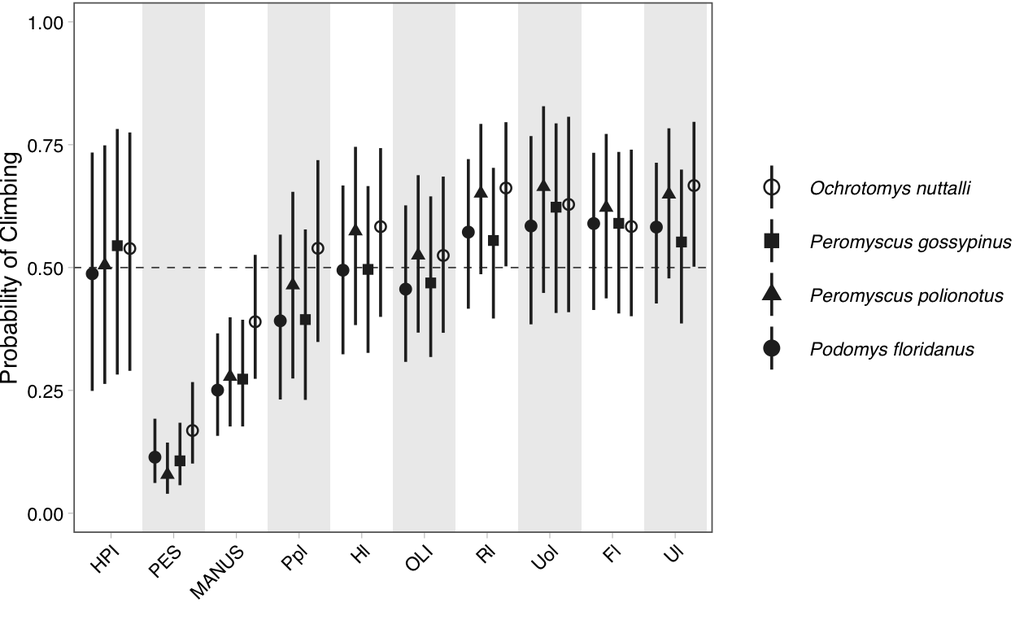

```r
# Example call
hplot(mice)

ggsave(here("Plots", "Bin_Individual_Plots.pdf"), height = 8, width = 13)
```

# 7 Plots

Plotting all the measurments and the multiple regression

```r
preds <- read_csv(here("Data", "predictions_all_methods.csv")) |>
  filter(method == "Fixed_only") |>
  select(!method) |>
  mutate(var = "multi") |>
  bind_rows(read_csv(here("Data", "predictions_individual.csv")))
```

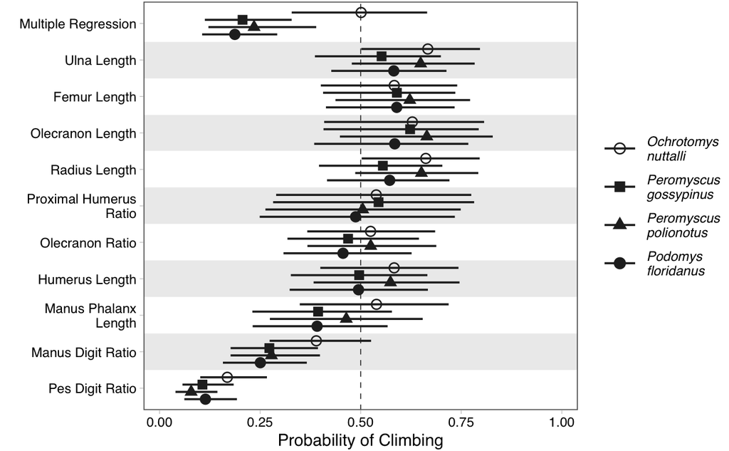

```r
var_acc <- c("PES", "MANUS", "Ppl", "Hl", "OLI", "HPI", "Rl", "Uol", "Fl", "Ul", "multi")
n_shades <- floor(length(var_acc) / 2)

shades <- data.frame(
  ymin = seq(1.5, by = 2, length.out = n_shades),
  ymax = seq(2.5, by = 2, length.out = n_shades),
  xmin = -Inf,
  xmax = Inf
)

preds %>%
  filter(Genus_species %in% mice,
         var %in% var_acc) %>%
  mutate(
    var           = as.factor(var),
    Genus_species = gsub("_", " ", Genus_species)
  ) %>%
  mutate(
  Genus_species = case_when(
    Genus_species == "Podomys floridanus"     ~ "Podomys\nfloridanus",
    Genus_species == "Ochrotomys nuttalli"    ~ "Ochrotomys\nnuttalli",
    Genus_species == "Peromyscus gossypinus"  ~ "Peromyscus\ngossypinus",
    Genus_species == "Peromyscus polionotus"  ~ "Peromyscus\npolionotus",
    TRUE ~ Genus_species
  )
) |>
  ggplot(aes(
    x     = Prob_of_Climbing,
    y     = fct_relevel(var, var_acc),
    shape = Genus_species
  )) +
  geom_rect(
    inherit.aes = FALSE,
    data        = shades,
    mapping     = aes(ymin = ymin, ymax = ymax, xmin = xmin, xmax = xmax),
    alpha       = 0.125
  ) +
  geom_vline(xintercept = 0.5, linetype = 2, linewidth = 0.35, color = "grey30") +
  stat_pointinterval(
    .width    = 0.8,
    color     = "grey15",
    size      = 7,
    linewidth = 1.7,
    position  = position_dodge(width = -0.8)
  ) +
  scale_x_continuous(limits = c(0, 1), expand = c(0.02, 0.02)) +
  scale_y_discrete(labels = c(
  "HPI"   = "Proximal Humerus\nRatio",
  "PES"   = "Pes Digit Ratio",
  "MANUS" = "Manus Digit Ratio",
  "OLI"   = "Olecranon Ratio",
  "Ppl"   = "Manus Phalanx\nLength",
  "Hl"    = "Humerus Length",
  "Rl"    = "Radius Length",
  "Uol"   = "Olecranon Length",
  "Ul"    = "Ulna Length",
  "Fl"    = "Femur Length",
  "multi" = "Multiple Regression"
  # etc.
)) +
  scale_shape_manual(values = c(1, 15, 17, 19, 8)) +
  labs(y = "", x = "Probability of Climbing") +
  ggthemes::theme_pander(gM = FALSE) +
  theme(
    axis.text.y  = element_text(angle = 0, hjust = 1),
    panel.border = element_rect(colour = "grey40", fill = NA, linewidth = 0.7),
    legend.text  = element_text(face = "italic"),
    legend.title = element_blank()
  ) +
  guides(shape = guide_legend(override.aes = list(size = 8)))

ggsave(here("Plots", "Probability_Plot_All.pdf"), height = 9, width = 6)
```

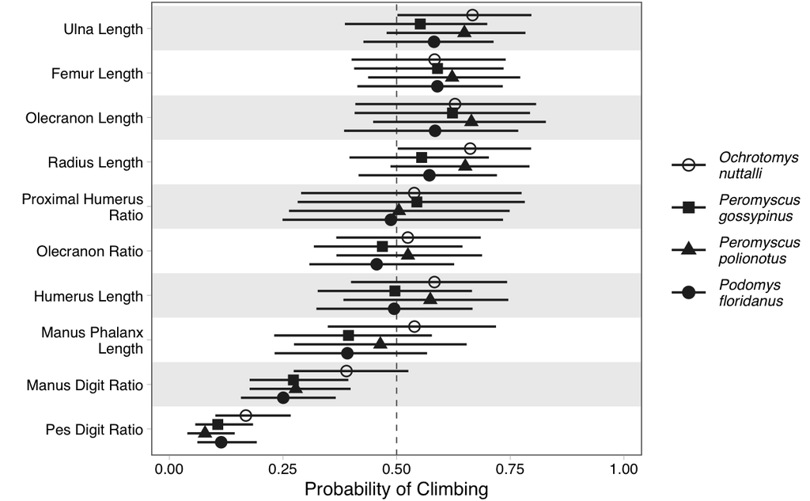

```r
var_acc <- c("PES", "MANUS", "Ppl", "Hl", "OLI", "HPI", "Rl", "Uol", "Fl", "Ul")
n_shades <- floor(length(var_acc) / 2)

shades <- data.frame(
  ymin = seq(1.5, by = 2, length.out = n_shades),
  ymax = seq(2.5, by = 2, length.out = n_shades),
  xmin = -Inf,
  xmax = Inf
)

preds %>%
  filter(Genus_species %in% mice,
         var %in% var_acc) %>%
  mutate(
    var           = as.factor(var),
    Genus_species = gsub("_", " ", Genus_species)
  ) %>%
  mutate(
  Genus_species = case_when(
    Genus_species == "Podomys floridanus"     ~ "Podomys\nfloridanus",
    Genus_species == "Ochrotomys nuttalli"    ~ "Ochrotomys\nnuttalli",
    Genus_species == "Peromyscus gossypinus"  ~ "Peromyscus\ngossypinus",
    Genus_species == "Peromyscus polionotus"  ~ "Peromyscus\npolionotus",
    TRUE ~ Genus_species
  )
) |>
  ggplot(aes(
    x     = Prob_of_Climbing,
    y     = fct_relevel(var, var_acc),
    shape = Genus_species
  )) +
  geom_rect(
    inherit.aes = FALSE,
    data        = shades,
    mapping     = aes(ymin = ymin, ymax = ymax, xmin = xmin, xmax = xmax),
    alpha       = 0.125
  ) +
  geom_vline(xintercept = 0.5, linetype = 2, linewidth = 0.35, color = "grey30") +
  stat_pointinterval(
    .width    = 0.8,
    color     = "grey15",
    size      = 7,
    linewidth = 1.7,
    position  = position_dodge(width = -0.8)
  ) +
  scale_x_continuous(limits = c(0, 1), expand = c(0.02, 0.02)) +
  scale_y_discrete(labels = c(
  "HPI"   = "Proximal Humerus\nRatio",
  "PES"   = "Pes Digit Ratio",
  "MANUS" = "Manus Digit Ratio",
  "OLI"   = "Olecranon Ratio",
  "Ppl"   = "Manus Phalanx\nLength",
  "Hl"    = "Humerus Length",
  "Rl"    = "Radius Length",
  "Uol"   = "Olecranon Length",
  "Ul"    = "Ulna Length",
  "Fl"    = "Femur Length"
  # etc.
)) +
  scale_shape_manual(values = c(1, 15, 17, 19, 8)) +
  labs(y = "", x = "Probability of Climbing") +
  ggthemes::theme_pander(gM = FALSE) +
  theme(
    axis.text.y  = element_text(angle = 0, hjust = 1),
    panel.border = element_rect(colour = "grey40", fill = NA, linewidth = 0.7),
    legend.text  = element_text(face = "italic"),
    legend.title = element_blank()
  ) +
  guides(shape = guide_legend(override.aes = list(size = 8)))

ggsave(here("Plots", "Probability_Plot_Measurements.pdf"), height = 8, width = 6)
```

Plot just multiple regression

```r
var_acc <- c("multi")
n_shades <- floor(length(var_acc) / 2)


preds %>%
  filter(Genus_species %in% mice,
         var %in% var_acc) %>%
  mutate(
    var           = as.factor(var),
    Genus_species = gsub("_", " ", Genus_species)
  ) %>%
  mutate(
  Genus_species = case_when(
    Genus_species == "Podomys floridanus"     ~ "Podomys\nfloridanus",
    Genus_species == "Ochrotomys nuttalli"    ~ "Ochrotomys\nnuttalli",
    Genus_species == "Peromyscus gossypinus"  ~ "Peromyscus\ngossypinus",
    Genus_species == "Peromyscus polionotus"  ~ "Peromyscus\npolionotus",
    TRUE ~ Genus_species
  )
) |>
  ggplot(aes(
    x     = Prob_of_Climbing,
    y     = fct_relevel(var, var_acc),
    shape = Genus_species
  )) +
  geom_vline(xintercept = 0.5, linetype = 2, linewidth = 0.35, color = "grey30") +
  stat_pointinterval(
    .width    = 0.8,
    color     = "grey15",
    size      = 7,
    linewidth = 1.7,
    position  = position_dodge(width = -0.8)
  ) +
  scale_x_continuous(limits = c(0, 1), expand = c(0.02, 0.02)) +
  scale_y_discrete(labels = c(
  "multi" = "Multiple Regression"
  # etc.
)) +
  scale_shape_manual(values = c(1, 15, 17, 19, 8)) +
  labs(y = "", x = "Probability of Climbing") +
  ggthemes::theme_pander(gM = FALSE) +
  theme(
    axis.text.y  = element_text(angle = 0, hjust = 1),
    panel.border = element_rect(colour = "grey40", fill = NA, linewidth = 0.7),
    legend.text  = element_text(face = "italic"),
    legend.title = element_blank()
  ) +
  guides(shape = guide_legend(override.aes = list(size = 8)))

ggsave(here("Plots", "Probability_Plot_Multiple_Reg.pdf"), height = 2, width = 5)
```

[figure not shown]

```r
ggsave(here("Plots", "Probability_Plot_Multiple_Reg.png"), height = 2, width = 5)
```

Climbing probability contrasts

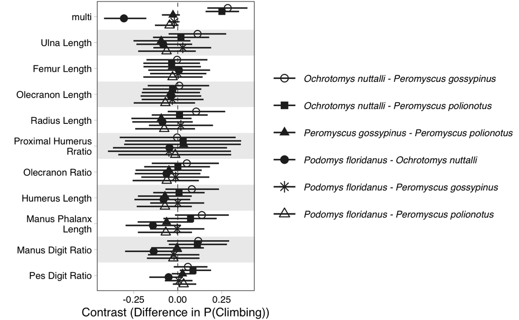

```r
library(tidyr)
library(stringr)
var_acc <- c("PES", "MANUS", "Ppl", "Hl", "OLI", "HPI", "Rl", "Uol", "Fl", "Ul", "multi")
n_shades <- floor(length(var_acc) / 2)
# All pairwise species combos
species_pairs <- combn(mice, 2, simplify = FALSE)

contrasts_df <- map_dfr(species_pairs, function(pair) {
  preds %>%
    filter(Genus_species %in% pair, var %in% var_acc) %>%
    pivot_wider(
      id_cols     = c(.draw, var),
      names_from  = Genus_species,
      values_from = Prob_of_Climbing
    ) %>%
    mutate(
      diff     = .[[pair[1]]] - .[[pair[2]]],
      contrast = paste0(gsub("_", " ", pair[1]), " - ", gsub("_", " ", pair[2]))
    ) %>%
    select(.draw, var, contrast, diff)
})

contrasts_df %>%
  mutate(var = factor(var, levels = var_acc)) %>%
  ggplot(aes(
    x     = diff,
    y     = fct_relevel(var, var_acc),
    shape = contrast
  )) +
  geom_rect(
    inherit.aes = FALSE,
    data        = shades,
    mapping     = aes(ymin = ymin, ymax = ymax, xmin = xmin, xmax = xmax),
    alpha       = 0.125
  ) +
  geom_vline(xintercept = 0, linetype = 2, linewidth = 0.35, color = "grey30") +
  stat_pointinterval(
    .width    = 0.9,
    color     = "grey15",
    size      = 7,
    linewidth = 1.7,
    position  = position_dodge(width = -0.8)
  ) +
  scale_shape_manual(values = c(1, 15, 17, 19, 8, 2, 0, 5, 6, 18)) +
  scale_y_discrete(labels = c(
    "HPI"   = "Proximal Humerus\nRratio",
    "PES"   = "Pes Digit Ratio",
    "MANUS" = "Manus Digit Ratio",
    "OLI"   = "Olecranon Ratio",
    "Ppl"   = "Manus Phalanx\nLength",
    "Hl"    = "Humerus Length",
    "Rl"    = "Radius Length",
    "Uol"   = "Olecranon Length",
    "Ul"    = "Ulna Length",
    "Fl"    = "Femur Length"
  )) +
  labs(y = "", x = "Contrast (Difference in P(Climbing))") +
  ggthemes::theme_pander(gM = FALSE) +
  theme(
    axis.text.y  = element_text(angle = 0, hjust = 1),
    panel.border = element_rect(colour = "grey40", fill = NA, linewidth = 0.7),
    legend.text  = element_text(face = "italic"),
    legend.title = element_blank()
  ) +
  guides(shape = guide_legend(override.aes = list(size = 8)))

ggsave(here("Plots", "Probability_Contrasts_All.pdf"), height = 10, width = 9)
```